# Genetic clustering for nutrition traits info

. Accessing genomic data and nutrition data: Read csv files of nutrition in data folder, and read the vcf file:

```r
library(dplyr)
library(vcfR)
accessions1 <- read.csv("data/CopyOfdf_traits_nutrition.csv")
genesys_data1<- accessions1 %>%
  mutate(acceNumb = gsub("PI ", "PI", acceNumb))
```

The following gives the genetic IDs of the 304 samples, and shows ow to access individual genomes.

```r
table1 = gt_file[,2] #access a single genome, pick numbers between 2 and 305
key_names = gt_file[0,] # access the names of the file as a matrix
attr(gt_file,"dimnames") # access the names of files as a list of character strings
```

```
[[1]]
NULL

[[2]]
  [1] "FORMAT"            "X11CS2572.2571"    "X12CS2536"         "X13CS1808"         "X13CS21123"        "X13CS21127"
  [7] "X13CS2134"         "X13CS221"          "X13CS3592"         "X14CS2180.2179"    "X14CS2360.2359"    "X14CS3450.3377"
 [13] "X14CS3450.3389"    "X14CS3450.3441"    "X14CS3450.3445"    "X14CS3450.3449"    "X15CS1912.1911"    "X15CS3315"
 [19] "X15FS279_NSZ"      "X15FS280_NSZ"      "X15FS281_NSZ"      "X15FS282_NSZ"      "X15FS283_NSZ"      "X15FS284_NSZ"
 [25] "X15FS285_NSZ"      "X15FS286_NSZ"      "X15FS287_NSZ"      "X15FS288_NSZ"      "X15FS289_NSZ"      "X15FS290_NSZ"
 [31] "X15FS291_NSZ"      "X15FS292_NSZ"      "X15FS293_NSZ"      "X15FS294_NSZ"      "X15FS295_NSZ"      "X15FS296_BTx623_P"
 [37] "X15FS297_NSZ_P"    "X15FS515_NSZ"      "X15WF2049.1"       "X15WF2088.1"       "X15WF2095.1"       "X15WF2101.1"
 [43] "X15WF2263.1"       "X16PR1252"         "X16PR1253"         "X16PR1254"         "X16PR1255"         "X16PR1256"
 [49] "X16PR1257"         "X16PR1258"         "X16PR1259"         "X16PR1260"         "X16PR1261"         "X16PR1262"
 [55] "X16PR1263"         "X16PR1264"         "X16PR1265"         "X16PR1266"         "X16PR1268"         "X16PR1269"
 [61] "X16PR1270"         "X16PR1271"         "X16PR1272"         "X16PR1273"         "X16PR1274"         "X16PR1275"
```

[output cut: 40 more lines]

```r
PI_tables=gt_file[,startsWith(colnames(gt_file),"PI")] # creates a table of genomes whose IDs begin with PI
```

Let’s now establish a distance function. We want to see how genomic distance correlates with different phenomic traits. Start with with Hamming Distance:

```r
hamming <- function(x,y) {
  if(length(x)!=length(y)){
    print('error, vectors not same size!')
  }else{
    result <- length(x[x!=y])

    return(result)
  }
}
hamming_mag <- function(x) {
  result <- length(x[x!="0|0"])
  return(result)
}
```

Let’s also get a vector of distances to the reference. We can then plot the distances. Immediately we see that the source of the samples has an effect on the distance from the reference:

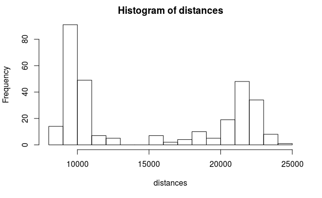

```r
distances <- vector()
for (i in 2:305){
  distances[i-1] <-hamming_mag(gt_file[,i])
}
hist(distances,breaks = 20)
```

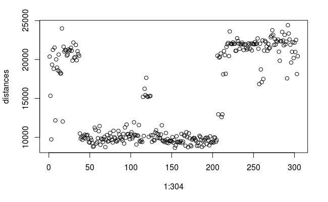

```r
plot(1:304,distances)
```

```r
hamming_mag(gt_file[,2])
```

```
[1] 20378
```

```r
order(distances)
```

```
  [1] 154 170  69 187  54 174  55 181 167 183 155 196 189 173  63 107 193  92  58 146 163  53 182  50 201 160 144 152  78 198
 [31] 199 158  59  49  66 141 114 159 126 204 157 112 164 200  72  83 150 180 149  82 161  73 147 111 188 140 148 139  90 129
 [61] 195 142  84 205 113 153 190  77 128 186  52  41  70 175 179  65   3  89  99 145  67 176  64  39 191  45  48  74 102 172
 [91]  60  81 135 136 178  51 177 133 194  43 203  94 192  87 202  80  88 169 151 185  76  40 122  68 103 197  98 156  42 166
[121] 116 184 109 106 108 127 125  46  71  47 165 105  44  86 137  97 134 100  96  91 162 132  38 171 143  75 130 101 168  61
[151]  85  79 131  57  56  93  62 138 110  95 104  17   8 211 212 207 115 121 123 120 124   2 118 117 257 260 262 291 119 213
[181] 303 216  14  15  13  11 259   6  10   4 296 282  29  34   9 299  31 208  32 209   1 304 220  37 206  22 215  23  12  36
[211] 210 301 297 281  19  35  25 214 267 228  28 229 263 248  21  20 238  26   5 242  24 233 246 256 269 243 241  27 270   7
[241] 217  18 266 287 275  33 239 295 277 245 251 237 235 218 234 289 240 250 253 224 223 268 226 227 258 247 222 232 249 254
[271] 244 219 300 236  30 225 298 265 252 279 290 284 283 278 231 264 286 261 302 280 294 276 255 230 271 272 288 274 293 285
[301] 221 273  16 292
```

```r
length(gt_file[,1])
```

```
[1] 70693
```

Now Let’s do something a bit more involved. We know that 00 differs from 01 in a way distinct from 11, so let’s record that. We can use, in particular, what is called the manhatan or cityblock distance. So |00-01|=|00-10|=|11-10|=|11-01|= 1, and |00-11|=|01-10|=2. But first, we must transform the genomic data into numeric form:

```r
#turns genomes into vectors with entries 0,1,2, where '0|0'-> 0; '0|1','1|0' ->1; '1|1'-> 2.
tonumericform <- function(a){
  if (class(a)=="numeric") {
    b<-matrix(nrow = length(gt_file[,1]),ncol=2)
    b[,]   <-0
    return(b)
    }
  else{
    vec<-matrix(nrow = length(a),ncol=2)
    vec[,1]<-as.numeric(substr(a, 1,1))
    vec[,2]<-as.numeric(substr(a, 3,3))
  return(vec)
  }
}
```

Now we define explicitly the cityblock distance. The cityblock distance should be at least the size of the hamming distance:

```r
#cityblock distance: to get a cityblock magnitude, set a2 to '0|0'.  This is similar to the l_1 distance of a vector
cityblock<- function(a1,a2){
  vec1<-tonumericform(a1)
  vec2<-tonumericform(a2)
  dif<- length(vec1[vec1[,1]!=vec2[,1],1])+length(vec1[vec1[,2]!=vec2[,2],1])
  return(dif)
}
print(hamming(gt_file[,2],gt_file[,3]))
```

```
[1] 27747
```

```r
print(cityblock(gt_file[,2],gt_file[,3]))
```

```
[1] 43710
```

We can similarly define Euclidean distance, which is in this case the 2-norm of the matrix formed by the genomic “difference”:

```r
#Euclidean distance: to get a Euclidean Magnitude, set a2 to '0|0''
euclidean<- function(a1,a2){
  vec1<-tonumericform(a1)
  vec2<-tonumericform(a2)
  dif <- norm(vec1-vec2,"2")
}
c<-print(euclidean(gt_file[,2],gt_file[,3]))
```

```
[1] 194.17
```

Let’s now chart the cityblock and Euclidean distances. It turns out that in general, the distances from the reference are comparable to eeach other.

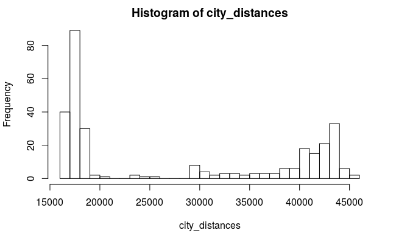

```r
city_distances <- vector()
for (i in 2:305){
  city_distances[i-1] <-cityblock(gt_file[,i],0)
  i
}
euclid_distances <- vector()
for (i in 2:305){
  euclid_distances[i-1] <-euclidean(gt_file[,i],0)
  i
}
hist(city_distances,breaks = 25)
```

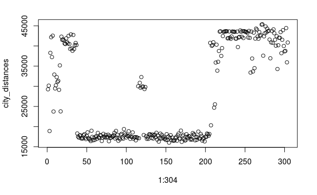

```r
plot(1:304,city_distances)
```

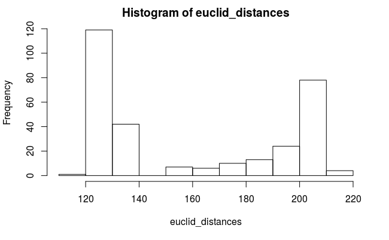

```r
hist(euclid_distances)
```

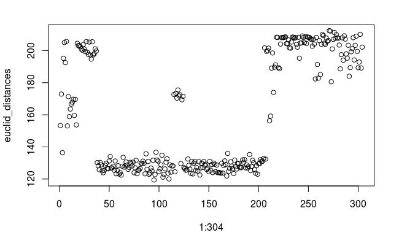

```r
plot(1:304,euclid_distances)
```

Without refering to the traits data, we can simply look at the clusters that are formed from each of the metrics:

The following creates a distance table for hamming, cityblock, and euclidean distances for all 304 samples (keep in mind that the latter two take longer):

```r
hd_matrix <- matrix(,nrow=304,ncol=304)
for(i in 1:304){
  for(j in i:304){
    hd_matrix[i,j] <- hamming(gt_file[,i+1],gt_file[,j+1])
    hd_matrix[j,i] <- hd_matrix[i,j]
  }
  if (i%%20 == 0) print(i)
}
```

```
[1] 20
[1] 40
[1] 60
[1] 80
[1] 100
[1] 120
[1] 140
[1] 160
[1] 180
[1] 200
[1] 220
[1] 240
[1] 260
[1] 280
[1] 300
```

```r
cd_matrix <- matrix(,nrow=304,ncol=304)
for(i in 1:304){
  for(j in i:304){
    cd_matrix[i,j] <- cityblock(gt_file[,i+1],gt_file[,j+1])
    cd_matrix[j,i] <- cd_matrix[i,j]
  }
  if (i%%20 == 0) print(i)
}
```

```
[1] 20
[1] 40
[1] 60
[1] 80
[1] 100
[1] 120
[1] 140
[1] 160
[1] 180
[1] 200
[1] 220
[1] 240
[1] 260
[1] 280
[1] 300
```

```r
ed_matrix <- matrix(,nrow=304,ncol=304)
for(i in 1:304){
  for(j in i:304){
    ed_matrix[i,j] <- euclidean(gt_file[,i+1],gt_file[,j+1])
    ed_matrix[j,i] <- ed_matrix[i,j]
  }
  if (i%%20 == 0) print(i)
}
```

```
[1] 20
[1] 40
[1] 60
[1] 80
[1] 100
[1] 120
[1] 140
[1] 160
[1] 180
[1] 200
[1] 220
[1] 240
[1] 260
[1] 280
[1] 300
```

Let’s now determine some clusters specific to each metric. for this, we use the dendextend package, since it contains extra visual enhancements for dendrograms, which we use to viusalize the clusters. The function in play for creating the clusters is hclust:

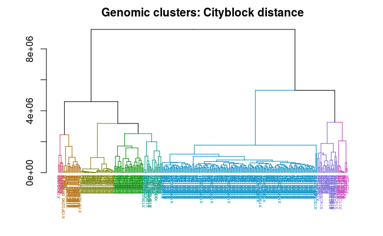

```r
#Cluster groups for the cityblock metric
library(dendextend)
create_dendro <-function(matrix,str_method,label_size,num_clust,label_list){
  tree<- hclust(dist(matrix,method = str_method)) %>%
  as.dendrogram() %>%  #sets the cluregin as a dendrogram so that we can customize it and plot it.
  set("labels_cex", label_size) %>%
  set("labels_col",values = 1:num_clust,k=num_clust) %>%
  set("branches_k_col", values = 1:num_clust, k = num_clust)

  labels(tree)<- label_list[order.dendrogram(tree)]

  return(tree)
}
#creates a clustering with set labels, label coloring, k= number of clusters, here set to 8, and label names set to size 0.5
ct_tree1 <-create_dendro(cd_matrix,"manhattan",0.5,8,colnames(gt_file))
  plot(ct_tree1,main='Genomic clusters: Cityblock distance')
```

We do the same with the hamming and euclidean distances…

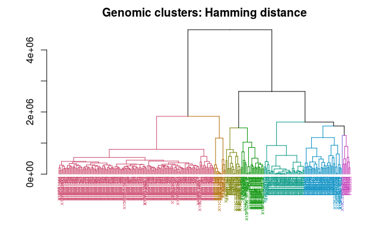

[figure not shown]

How do these clusterings depend on the distance? We can get a sense of this by comparing trees against each other. The following code creates and saves an image of two dendrograms, but with the first having labels colored according to their clusters, while the second has the same labels, but with the original colors of the first clustering. This enables us to see to what extent the values changed.

```r
#Comparing cityblock with hamming: cityblock on left, hamming on right
#sets colors for hamming labels to be the same as those in the cityblock for each geneticID
  newcolors<-labels_col(ct_tree2)[]
  for (i in 1:304){
    newcolors[i]<-labels_col(ct_tree1)[which(labels(ct_tree1)==labels(ct_tree2)[i])]
  }

  #ct_tree2 %<%set("labels_col",values= newcolors)

  labels_colors(ct_tree2)<- newcolors
png("largeCLustersCityHamming.png",height = 2000,width = 2000)
par(mfrow = c(1,2))
plot(ct_tree1,main="Cityblock Clusters",horiz=TRUE)
plot_horiz.dendrogram(ct_tree2,main ="Hamming Clusters",side=TRUE)
```

```r
dev.off()
```

We can do the same with Hamming vs Euclidean… Both examples show that while certain clusters are for the most part retained, there are differences in the clustering itself. This is important to keep in mind when trying to find correspondences between genetic distances and phenomic traits.

```r
#Comparing cityblock with hamming: cityblock on left, hamming on right
#sets colors for hamming labels to be the same as those in the cityblock for each geneticID
  newcolors<-labels_col(ct_tree2)[]
  for (i in 1:304){
    newcolors[i]<-labels_col(ct_tree3)[which(labels(ct_tree3)==labels(ct_tree2)[i])]
  }

  #ct_tree2 %<%set("labels_col",values= newcolors)

  labels_colors(ct_tree2)<- newcolors
png("largeCLustersEuclidHamming.png",height = 2000,width = 2000)
par(mfrow = c(1,2))
plot(ct_tree3,main="Euclidean Clusters",horiz=TRUE)
plot_horiz.dendrogram(ct_tree2,main ="Hamming Clusters",side=TRUE)
```

```r
dev.off()
```

It turns out that we did not have phenomic data for each sample in the vcf file, but we had some phenomic information on some of the samples. In order to get some genomic data, we need to focus on the samples that have more data in a different source. For this we used gensys.

Now we extract the genomes present in both the vcf file and the genesys data.

```r
# extract the genetic ID names from the gt file
colnames(gt_file)<-gsub(".MERGE", "",colnames(gt_file))
#sort genesys nutrion data
genesys_data_sorted1 <- genesys_data1[order(genesys_data1$acceNumb),]
#find IDS present in both the vcf files and the nutrition traits file, done twoce but with different syntax to check that files were matched.
match_vcf1<-colnames(gt_file) %in% genesys_data_sorted1$acceNumb
colnames(gt_file)[match_vcf1]
```

```
 [1] "PI510904" "PI510907" "PI510917" "PI510921" "PI510922" "PI510923" "PI510924" "PI510925" "PI510931" "PI510934" "PI510946"
[12] "PI510948" "PI510950" "PI510951" "PI510972" "PI510974" "PI510977" "PI510991" "PI510993" "PI510994" "PI511002" "PI511011"
[23] "PI511015" "PI511016" "PI511018" "PI560493" "PI562777" "PI563068" "PI563392" "PI563398" "PI563409" "PI563430" "PI563447"
[34] "PI563448" "PI563449" "PI563450" "PI563451" "PI563452" "PI563453" "PI563454" "PI563455" "PI563485" "PI565120" "PI569812"
[45] "PI585368" "PI585369" "PI585373" "PI585379"
```

```r
#sort the files
match_genesys1<- genesys_data_sorted1$acceNumb  %in% colnames(gt_file)
genesys_data_sorted1[match_genesys1,]$acceNumb
```

```
 [1] "PI510904" "PI510907" "PI510917" "PI510921" "PI510922" "PI510923" "PI510924" "PI510925" "PI510931" "PI510934" "PI510946"
[12] "PI510948" "PI510950" "PI510951" "PI510972" "PI510974" "PI510977" "PI510991" "PI510993" "PI510994" "PI511002" "PI511011"
[23] "PI511015" "PI511016" "PI511018" "PI560493" "PI562777" "PI563068" "PI563392" "PI563398" "PI563409" "PI563430" "PI563447"
[34] "PI563448" "PI563449" "PI563450" "PI563451" "PI563452" "PI563453" "PI563454" "PI563455" "PI563485" "PI565120" "PI569812"
[45] "PI585368" "PI585369" "PI585373" "PI585379"
```

```r
genesys_data_match1 <- genesys_data_sorted1[match_genesys1,]
vcf_gt_match1 <- gt_file[,match_vcf1]
```

Thre are 48 matches in the data. Let us now look at the clusters that are formed from each of the metrics:

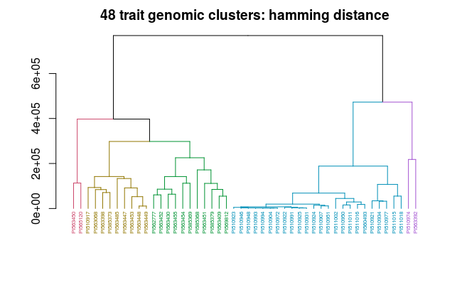

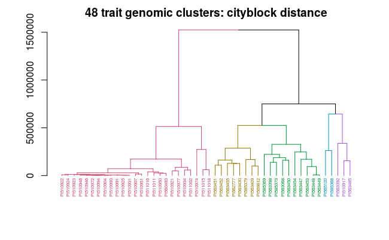

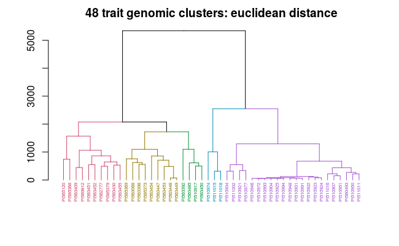

```r
ct_tree48_1 <-create_dendro(hd_matrix48, num_clust = 5,label_list = colnames(vcf_gt_match1))
ct_tree48_2 <-create_dendro(cd_matrix48, num_clust = 5,label_list = colnames(vcf_gt_match1))
ct_tree48_3 <-create_dendro(ed_matrix48, num_clust = 5,label_list = colnames(vcf_gt_match1))
  plot(ct_tree48_1,main='48 trait genomic clusters: hamming distance')
  plot(ct_tree48_2,main='48 trait genomic clusters: cityblock distance')

  plot(ct_tree48_3,main='48 trait genomic clusters: euclidean distance')
```

Comparing hamming and cityblock distance clusterings

```r
#change colors of cityblock distance labels to match hamming labels
  oldcolors<- labels_col(ct_tree48_2)[]
  newcolors<-labels_col(ct_tree48_2)[]
  for (i in 1:48){
    newcolors[i]<-labels_col(ct_tree48_1)[which(labels(ct_tree48_1)==labels(ct_tree48_2)[i])]
  }
  newcolors
```

```
 PI510922  PI510924  PI510923  PI510948  PI510946  PI510972  PI510994  PI510904  PI510993  PI510991  PI510925  PI510931
"#008FB7" "#008FB7" "#008FB7" "#008FB7" "#008FB7" "#008FB7" "#008FB7" "#008FB7" "#008FB7" "#008FB7" "#008FB7" "#008FB7"
 PI510907  PI510951  PI511016  PI511011  PI510950  PI560493  PI510921  PI510977  PI510934  PI511002  PI510974  PI511015
"#008FB7" "#008FB7" "#008FB7" "#008FB7" "#008FB7" "#008FB7" "#008FB7" "#008FB7" "#008FB7" "#008FB7" "#A352D1" "#008FB7"
 PI511018  PI563451  PI563452  PI563455  PI562777  PI563430  PI585379  PI563409  PI569812  PI585369  PI563398  PI585373
"#008FB7" "#009232" "#009232" "#009232" "#009232" "#009232" "#009232" "#009232" "#009232" "#009232" "#917600" "#917600"
 PI563068  PI563450  PI563454  PI563447  PI563453  PI563448  PI563449  PI565120  PI585368  PI563392  PI510917  PI563485
"#917600" "#CC476B" "#009232" "#917600" "#917600" "#917600" "#917600" "#CC476B" "#009232" "#A352D1" "#917600" "#917600"
```

```r
  labels_colors(ct_tree48_2)<-newcolors
par(mfrow=c(1,2))
plot(ct_tree48_1, main="nutrition trait hamming clusters",horiz=TRUE)
plot_horiz.dendrogram(ct_tree48_2,main="nutrition trait cityblock clusters",side=TRUE)
```

```r
png("dual48clustersHammingCityblock.png", width = 600)
par(mfrow=c(1,2))
plot(ct_tree48_1, main="48 trait hamming clusters",horiz=TRUE)
```

[figure not shown]

```r
plot_horiz.dendrogram(ct_tree48_2,main="48 trait cityblock clusters",side=TRUE)
dev.off()
```

```r
#restore the original color of the labels for the cityblock dendrogram
labels_colors(ct_tree48_2)<-oldcolors
```

Comparing cityblock and euclidean

```r
#change colors of euclidean distance labels to match cityblock labels
  oldcolors<- labels_col(ct_tree48_3)[]
  newcolors<-labels_col(ct_tree48_3)[]
  for (i in 1:48){
    newcolors[i]<-labels_col(ct_tree48_2)[which(labels(ct_tree48_2)==labels(ct_tree48_3)[i])]
  }
  newcolors
```

```
 PI565120  PI585368  PI563409  PI569812  PI563451  PI563452  PI562777  PI585379  PI563430  PI563455  PI585369  PI563068
"#008FB7" "#008FB7" "#917600" "#917600" "#917600" "#917600" "#917600" "#917600" "#917600" "#917600" "#009232" "#009232"
 PI563398  PI585373  PI563454  PI563447  PI563453  PI563448  PI563449  PI563392  PI563485  PI510917  PI563450  PI510974
"#009232" "#009232" "#009232" "#009232" "#009232" "#009232" "#009232" "#A352D1" "#A352D1" "#A352D1" "#009232" "#CC476B"
 PI511015  PI511018  PI510934  PI511002  PI510921  PI510977  PI510946  PI510972  PI510993  PI510904  PI510925  PI510994
"#CC476B" "#CC476B" "#CC476B" "#CC476B" "#CC476B" "#CC476B" "#CC476B" "#CC476B" "#CC476B" "#CC476B" "#CC476B" "#CC476B"
 PI510948  PI510931  PI510991  PI510922  PI510923  PI510924  PI511016  PI510907  PI510951  PI560493  PI510950  PI511011
"#CC476B" "#CC476B" "#CC476B" "#CC476B" "#CC476B" "#CC476B" "#CC476B" "#CC476B" "#CC476B" "#CC476B" "#CC476B" "#CC476B"
```

```r
  labels_colors(ct_tree48_3)<-newcolors
par(mfrow=c(1,2))
plot(ct_tree48_2, main="48 sample: cityblock clusters",horiz=TRUE)
plot_horiz.dendrogram(ct_tree48_3,main="48 sample: euclidean clusters",side=TRUE)
```

```r
par(mfrow=c(1,2))
png("dual48clustersCityEuclidean.png",width = 600)
```

```r
par(mfrow=c(1,2))
plot(ct_tree48_2,main="48-trait cityblock clusters",horiz=TRUE)
plot_horiz.dendrogram(ct_tree48_3,main="48-trait euclidean clusters",side=TRUE)
```

[figure not shown]

```r
dev.off()
```

Now create a table containing all the growth traits

```r
#create a table containing all of the traits from each csv file
library(dplyr)
for(i in seq_along(files)){
  next_table <- read.csv(files[i])
  next_table$datasetId <- NULL
  colnames(next_table)[colnames(next_table) == 'value'] <- tables[i]
  accessions <- left_join(accessions, next_table, by = 'genesysId')
}
```

```
cannot open file 'anthesis1.csv': No such file or directoryError in file(file, "rt") : cannot open the connection
```

Extract the matching growth data genetic ids

```r
genesys_data_sorted2 <- genesys_data2[order(genesys_data2$acceNumb),]
genesys_data_sorted2 <- genesys_data2[order(genesys_data2$acceNumb),]
match_vcf2<-colnames(gt_file) %in% genesys_data_sorted2$acceNumb
colnames(gt_file)[match_vcf2]
```

```
 [1] "PI585346" "PI585347" "PI585348" "PI585349" "PI585350" "PI585351" "PI585353" "PI585355" "PI585359" "PI585363" "PI585365"
[12] "PI585368" "PI585369" "PI585372" "PI585373" "PI585374" "PI585376" "PI585379" "PI586046"
```

```r
match_genesys2<- genesys_data_sorted2$acceNumb  %in% colnames(gt_file)
genesys_data_sorted2[match_genesys2,]$acceNumb
```

```
 [1] "PI585346" "PI585347" "PI585348" "PI585349" "PI585350" "PI585351" "PI585353" "PI585355" "PI585359" "PI585363" "PI585365"
[12] "PI585368" "PI585369" "PI585372" "PI585373" "PI585374" "PI585376" "PI585379" "PI586046"
```

```r
genesys_data_match2 <- genesys_data_sorted2[match_genesys2,]
vcf_gt_match2 <- gt_file[,match_vcf2]
```

manhattan

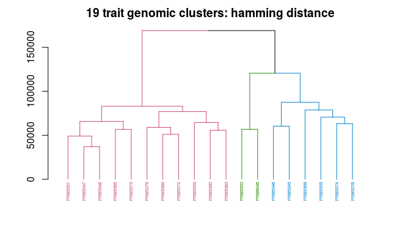

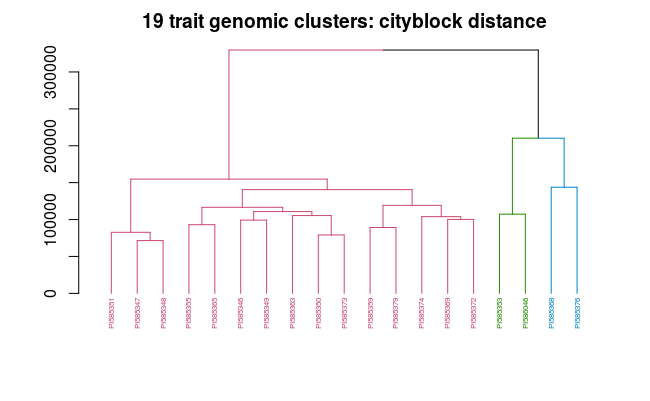

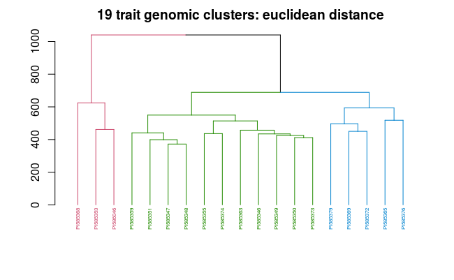

```r
ct_tree19_1 <-create_dendro(hd_matrix19, num_clust = 3,label_list = colnames(vcf_gt_match2))
ct_tree19_2 <-create_dendro(cd_matrix19, num_clust = 3,label_list = colnames(vcf_gt_match2))
ct_tree19_3 <-create_dendro(ed_matrix19, num_clust = 3,label_list = colnames(vcf_gt_match2))
  plot(ct_tree19_1,main='19 trait genomic clusters: hamming distance')
  plot(ct_tree19_2,main='19 trait genomic clusters: cityblock distance')

  plot(ct_tree19_3,main='19 trait genomic clusters: euclidean distance')
```

```r
#change colors of cityblock distance labels to match hamming labels
  oldcolors<- labels_col(ct_tree19_2)[]
  newcolors<-labels_col(ct_tree19_2)[]
  for (i in 1:19){
    newcolors[i]<-labels_col(ct_tree19_1)[which(labels(ct_tree19_1)==labels(ct_tree19_2)[i])]
  }
  newcolors
```

```
 PI585351  PI585347  PI585348  PI585355  PI585365  PI585346  PI585349  PI585363  PI585350  PI585373  PI585359  PI585379
"#CC476B" "#CC476B" "#CC476B" "#0082CE" "#CC476B" "#0082CE" "#0082CE" "#CC476B" "#CC476B" "#CC476B" "#CC476B" "#CC476B"
 PI585374  PI585369  PI585372  PI585353  PI586046  PI585368  PI585376
"#0082CE" "#CC476B" "#CC476B" "#228B00" "#228B00" "#0082CE" "#0082CE"
```

```r
  labels_colors(ct_tree19_2)<-newcolors
par(mfrow=c(1,2))
plot(ct_tree19_1, main="growth trait hamming clusters",horiz=TRUE)
plot_horiz.dendrogram(ct_tree19_2,main="growth trait cityblock clusters",side=TRUE)
```

```r
png("dual19clustersHammingCityblock.png", width = 600)
par(mfrow=c(1,2))
plot(ct_tree19_1, main="19 trait hamming clusters",horiz=TRUE)
```

[figure not shown]

```r
plot_horiz.dendrogram(ct_tree19_2,main="19 trait cityblock clusters",side=TRUE)
dev.off()
```

```r
#restore the original color of the labels for the cityblock dendrogram
labels_colors(ct_tree19_2)<-oldcolors
```

euclidean

```r
#change colors of euclidean distance labels to match hamming labels
  oldcolors<- labels_col(ct_tree19_3)[]
  newcolors<-labels_col(ct_tree19_3)[]
  for (i in 1:19){
    newcolors[i]<-labels_col(ct_tree19_1)[which(labels(ct_tree19_1)==labels(ct_tree19_3)[i])]
  }
  newcolors
```

```
 PI585368  PI585353  PI586046  PI585359  PI585351  PI585347  PI585348  PI585355  PI585374  PI585363  PI585346  PI585349
"#0082CE" "#228B00" "#228B00" "#CC476B" "#CC476B" "#CC476B" "#CC476B" "#0082CE" "#0082CE" "#CC476B" "#0082CE" "#0082CE"
 PI585350  PI585373  PI585379  PI585369  PI585372  PI585365  PI585376
"#CC476B" "#CC476B" "#CC476B" "#CC476B" "#CC476B" "#CC476B" "#0082CE"
```

```r
  labels_colors(ct_tree19_3)<-newcolors
par(mfrow=c(1,2))
plot(ct_tree19_1, main="growth trait hamming clusters",horiz=TRUE)
plot_horiz.dendrogram(ct_tree19_3,main="growth trait euclidean clusters",side=TRUE)
```

```r
png("dual19clustersHammingEuclidean.png", width = 600)
par(mfrow=c(1,2))
plot(ct_tree19_1, main="19 trait hamming clusters",horiz=TRUE)
```

[figure not shown]

```r
plot_horiz.dendrogram(ct_tree19_3,main="19 trait euclidean clusters",side=TRUE)
dev.off()
```

```r
#restore the original color of the labels for the cityblock dendrogram
labels_colors(ct_tree19_3)<-oldcolors
```